# Network Analysis: Monk Data Set

A closer look.

Peter Sullivan  
2022-04-04

## Investigate the Network

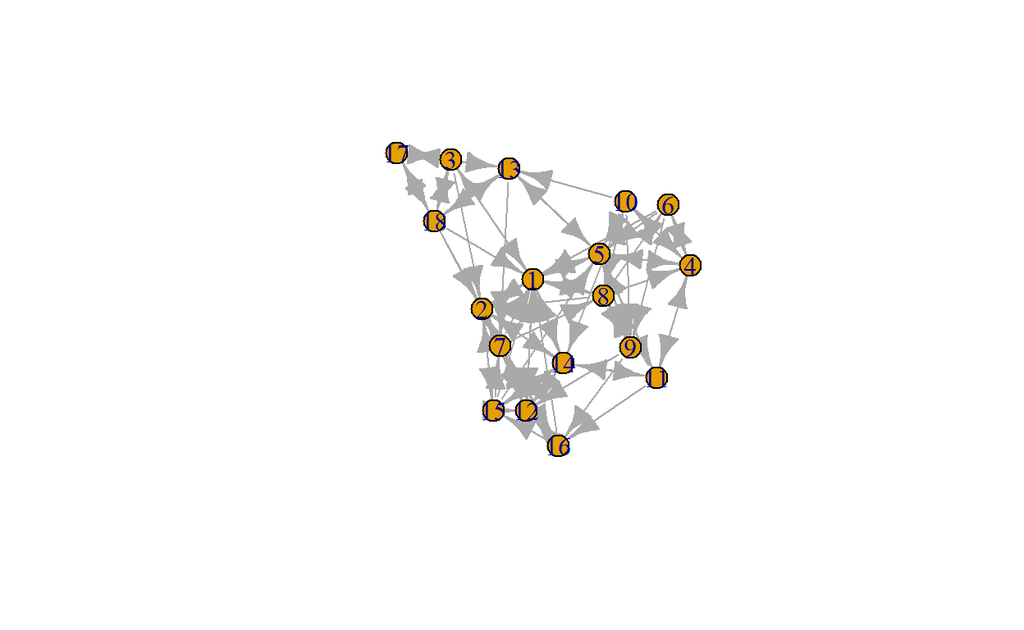

```r
plot(network_igraph)
```

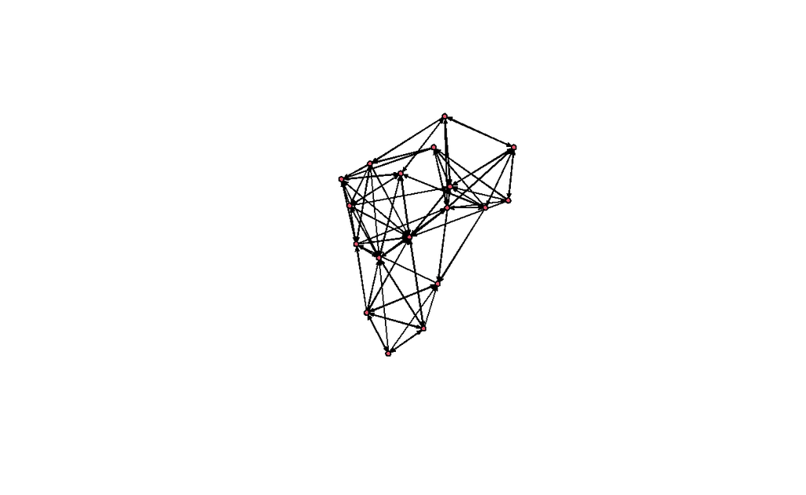

```r
plot(network_statnet)
```

```r
print(network_statnet)
```

```
 Network attributes:
  vertices = 18
  directed = TRUE
  hyper = FALSE
  loops = FALSE
  multiple = FALSE
  total edges= 88
    missing edges= 0
    non-missing edges= 88

 Vertex attribute names:
    cloisterville group vertex.names

 Edge attribute names:
    nominations
```

We have 18 nodes with 88 edges, and a directed network.

### Weighted, Directed, and Bipartile?

```r
is_bipartite(network_igraph)
```

```
[1] FALSE
```

```r
is_directed(network_igraph)
```

```
[1] TRUE
```

```r
is_weighted(network_igraph)
```

```
[1] FALSE
```

Looking at Igraph and Statnet, I have confirmed that this is a single mode, directed, and unweighted dataset.

## Dyads, Triads, and Component Structure

### Dyads and Triads

```r
sna::dyad.census(network_statnet)
```

```
     Mut Asym Null
[1,]  28   32   93
```

```r
sna::triad.census(network_statnet)
```

```
     003 012 102 021D 021U 021C 111D 111U 030T 030C 201 120D 120U
[1,] 167 205 190   12   24   24   68   34    5    0  35   15    6
     120C 210 300
[1,]    5  18   8
```

### Transitivity

```r
transitivity(network_igraph, type = "global")
```

```
[1] 0.4646739
```

```r
transitivity(network_igraph, type = "average")
```

```
[1] 0.4925926
```

The average transitivity is slightly higher than the global transitivity. This could be do to certain small clusters with high transitivity.

### Component Structure

```r
igraph::components(network_igraph)$no
```

```
[1] 1
```

```r
igraph::components(network_igraph)$csize
```

```
[1] 18
```

```r
isolates(network_statnet)
```

```
integer(0)
```

From the componenet structure and after verifying with the plot of the network, we have no isolates in the network.

## Dataframe of Centrality Scores

```r
network::list.vertex.attributes(network_statnet)
```

```
[1] "cloisterville" "group"         "na"            "vertex.names"
```

```r
network.nodes <- data.frame(name = network_statnet%v%"vertex.names",
                            totdegree = sna::degree(network_statnet),
                            in.degree = sna::degree(network_statnet, cmode = "indegree"),
                            out.degree = sna::degree(network_statnet, cmode = "outdegree"),
                            eigen = round(sna::evcent(network_statnet),3),
                            Bonacich.Power = round(sna::bonpow(network_statnet),3))

rownames(network.nodes)<- NULL
network.nodes %>% arrange(desc(eigen)) %>% head() %>% knitr::kable()
```

| name | totdegree | in.degree | out.degree | eigen | Bonacich.Power |
| --- | --- | --- | --- | --- | --- |
| Boniface | 9 | 3 | 6 | 0.298 | -0.845 |
| John Bosco | 17 | 11 | 6 | 0.288 | -1.422 |
| Simplicius | 9 | 3 | 6 | 0.275 | -1.299 |
| Victor | 11 | 5 | 6 | 0.266 | -1.217 |
| Gregory | 15 | 10 | 5 | 0.264 | -0.685 |
| Albert | 8 | 3 | 5 | 0.264 | -0.411 |

```r
network.nodes %>% arrange(desc(Bonacich.Power)) %>% head() %>%knitr::kable()
```

| name | totdegree | in.degree | out.degree | eigen | Bonacich.Power |
| --- | --- | --- | --- | --- | --- |
| Ambrose | 8 | 4 | 4 | 0.190 | -0.322 |
| Albert | 8 | 3 | 5 | 0.264 | -0.411 |
| Mark | 11 | 6 | 5 | 0.259 | -0.597 |
| Winfrid | 11 | 7 | 4 | 0.214 | -0.640 |
| Gregory | 15 | 10 | 5 | 0.264 | -0.685 |
| Amand | 8 | 5 | 3 | 0.148 | -0.705 |

Boniface and John Bosco have the highest eigen centrality. Even though Boniface only has 9 total degress while john bosco has 17 degrees. When looking at Bonacich Power, Ambrose and Alber seem to have the highest at -.3 and -.411.

### Derived and Reflected Centrality

```r
## Reflected Centrality
mat_flor <- as.matrix(as_adjacency_matrix(network_igraph))
mat_flor.sq <- t(mat_flor) %*% mat_flor

network.nodes$rc <- round(diag(mat_flor.sq)/rowSums(mat_flor.sq),3)

network.nodes$rc <- ifelse(is.nan(network.nodes$rc),0,network.nodes$rc)

network.nodes$eigen.rc <- round(network.nodes$eigen*network.nodes$rc,3)

## Derived Centrality


network.nodes$dc <- round(1 - diag(mat_flor.sq)/rowSums(mat_flor.sq),3)

network.nodes$dc <- ifelse(is.nan(network.nodes$dc),1,network.nodes$dc)

network.nodes$eigen.dc <- round(network.nodes$eigen*network.nodes$dc,3)


network.nodes%>%arrange(desc(eigen.dc)) %>% head() %>% knitr::kable()
```

| name | totdegree | in.degree | out.degree | eigen | Bonacich.Power | rc | eigen.rc | dc | eigen.dc |
| --- | --- | --- | --- | --- | --- | --- | --- | --- | --- |
| Boniface | 9 | 3 | 6 | 0.298 | -0.845 | 0.200 | 0.060 | 0.800 | 0.238 |
| John Bosco | 17 | 11 | 6 | 0.288 | -1.422 | 0.196 | 0.056 | 0.804 | 0.232 |
| Victor | 11 | 5 | 6 | 0.266 | -1.217 | 0.192 | 0.051 | 0.808 | 0.215 |
| Gregory | 15 | 10 | 5 | 0.264 | -0.685 | 0.192 | 0.051 | 0.808 | 0.213 |
| Hugh | 11 | 6 | 5 | 0.259 | -0.959 | 0.188 | 0.049 | 0.812 | 0.210 |
| Albert | 8 | 3 | 5 | 0.264 | -0.411 | 0.214 | 0.056 | 0.786 | 0.208 |

```r
network.nodes%>%arrange(desc(eigen.rc)) %>% head() %>% knitr::kable()
```

| name | totdegree | in.degree | out.degree | eigen | Bonacich.Power | rc | eigen.rc | dc | eigen.dc |
| --- | --- | --- | --- | --- | --- | --- | --- | --- | --- |
| Simplicius | 9 | 3 | 6 | 0.275 | -1.299 | 0.250 | 0.069 | 0.750 | 0.206 |
| Boniface | 9 | 3 | 6 | 0.298 | -0.845 | 0.200 | 0.060 | 0.800 | 0.238 |
| John Bosco | 17 | 11 | 6 | 0.288 | -1.422 | 0.196 | 0.056 | 0.804 | 0.232 |
| Albert | 8 | 3 | 5 | 0.264 | -0.411 | 0.214 | 0.056 | 0.786 | 0.208 |
| Mark | 11 | 6 | 5 | 0.259 | -0.597 | 0.207 | 0.054 | 0.793 | 0.205 |
| Gregory | 15 | 10 | 5 | 0.264 | -0.685 | 0.192 | 0.051 | 0.808 | 0.213 |

For derived centrality the highest are Boniface and John Bosco. For received centrality, Samplicuius, Boniface and JOhn Bosco are at the top. John Bosco and Boniface must have some real pull in this monk group.

## Calculate Closeness Centrality

```r
network.nodes$closeness<-round(sna::closeness(network_statnet, gmode = "graph", cmode = "suminvundir"),3)

network.nodes %>% arrange(desc(closeness)) %>% knitr::kable()
```

| name | totdegree | in.degree | out.degree | eigen | Bonacich.Power | rc | eigen.rc | dc | eigen.dc | closeness |
| --- | --- | --- | --- | --- | --- | --- | --- | --- | --- | --- |
| John Bosco | 17 | 11 | 6 | 0.288 | -1.422 | 0.196 | 0.056 | 0.804 | 0.232 | 0.824 |
| Gregory | 15 | 10 | 5 | 0.264 | -0.685 | 0.192 | 0.051 | 0.808 | 0.213 | 0.794 |
| Bonaventure | 13 | 8 | 5 | 0.206 | -1.076 | 0.211 | 0.043 | 0.789 | 0.163 | 0.735 |
| Mark | 11 | 6 | 5 | 0.259 | -0.597 | 0.207 | 0.054 | 0.793 | 0.205 | 0.735 |
| Victor | 11 | 5 | 6 | 0.266 | -1.217 | 0.192 | 0.051 | 0.808 | 0.215 | 0.735 |
| Boniface | 9 | 3 | 6 | 0.298 | -0.845 | 0.200 | 0.060 | 0.800 | 0.238 | 0.706 |
| Albert | 8 | 3 | 5 | 0.264 | -0.411 | 0.214 | 0.056 | 0.786 | 0.208 | 0.706 |
| Winfrid | 11 | 7 | 4 | 0.214 | -0.640 | 0.194 | 0.042 | 0.806 | 0.172 | 0.696 |
| Romauld | 8 | 2 | 6 | 0.248 | -1.005 | 0.200 | 0.050 | 0.800 | 0.198 | 0.676 |
| Amand | 8 | 5 | 3 | 0.148 | -0.705 | 0.192 | 0.028 | 0.808 | 0.120 | 0.676 |
| Hugh | 11 | 6 | 5 | 0.259 | -0.959 | 0.188 | 0.049 | 0.812 | 0.210 | 0.676 |
| Ambrose | 8 | 4 | 4 | 0.190 | -0.322 | 0.190 | 0.036 | 0.810 | 0.154 | 0.647 |
| Simplicius | 9 | 3 | 6 | 0.275 | -1.299 | 0.250 | 0.069 | 0.750 | 0.206 | 0.647 |
| Berthold | 6 | 2 | 4 | 0.171 | -1.057 | 0.200 | 0.034 | 0.800 | 0.137 | 0.637 |
| Basil | 8 | 3 | 5 | 0.231 | -1.378 | 0.188 | 0.043 | 0.812 | 0.188 | 0.618 |
| Louis | 8 | 3 | 5 | 0.233 | -1.145 | 0.214 | 0.050 | 0.786 | 0.183 | 0.618 |
| Peter | 9 | 5 | 4 | 0.172 | -1.260 | 0.192 | 0.033 | 0.808 | 0.139 | 0.608 |
| Elias | 6 | 2 | 4 | 0.183 | -1.045 | 0.182 | 0.033 | 0.818 | 0.150 | 0.578 |

```r
summary(network.nodes$closeness)
```

```
   Min. 1st Qu.  Median    Mean 3rd Qu.    Max.
 0.5780  0.6395  0.6760  0.6840  0.7278  0.8240
```

John Bosco is at the higest closeness centrality. This would be expected with such high received and derived centrality. Surpirsingly Boniface is not as close to the other nodes as John bosco.

## Closeness Centralization

```r
centr_clo(network_igraph)$centralization
```

```
[1] 0.0919023
```

I’m a bit confused why the closeness centraliztion is so much lower then average closeness seen above.

## Betweenness Centrality

```r
#igraph::betweenness(network_igraph, directed = FALSE)
network.nodes$betweenness <-round(sna::betweenness(network_statnet, gmode = "graph"),3)
network.nodes %>% arrange(desc(betweenness)) %>% head() %>% knitr::kable()
```

| name | totdegree | in.degree | out.degree | eigen | Bonacich.Power | rc | eigen.rc | dc | eigen.dc | closeness | betweenness |
| --- | --- | --- | --- | --- | --- | --- | --- | --- | --- | --- | --- |
| John Bosco | 17 | 11 | 6 | 0.288 | -1.422 | 0.196 | 0.056 | 0.804 | 0.232 | 0.824 | 34.477 |
| Bonaventure | 13 | 8 | 5 | 0.206 | -1.076 | 0.211 | 0.043 | 0.789 | 0.163 | 0.735 | 19.374 |
| Victor | 11 | 5 | 6 | 0.266 | -1.217 | 0.192 | 0.051 | 0.808 | 0.215 | 0.735 | 18.075 |
| Mark | 11 | 6 | 5 | 0.259 | -0.597 | 0.207 | 0.054 | 0.793 | 0.205 | 0.735 | 11.576 |
| Basil | 8 | 3 | 5 | 0.231 | -1.378 | 0.188 | 0.043 | 0.812 | 0.188 | 0.618 | 11.068 |
| Amand | 8 | 5 | 3 | 0.148 | -0.705 | 0.192 | 0.028 | 0.808 | 0.120 | 0.676 | 10.127 |

John Bosco has the highest closeness and the highest betweeness. This means that the John is receiving information the fastest out of all the familys and is also relied upon most in the network for for information.

## Betweenness Centralization

```r
centr_betw(network_igraph, directed = F)$centralization
```

```
[1] 0.1177914
```

## Network Constraint

```r
network.nodes$Constraint <- round(constraint(network_igraph),3)

network.nodes %>% arrange(desc(Constraint)) %>% head() %>% knitr::kable()
```

| name | totdegree | in.degree | out.degree | eigen | Bonacich.Power | rc | eigen.rc | dc | eigen.dc | closeness | betweenness | Constraint |
| --- | --- | --- | --- | --- | --- | --- | --- | --- | --- | --- | --- | --- |
| Elias | 6 | 2 | 4 | 0.183 | -1.045 | 0.182 | 0.033 | 0.818 | 0.150 | 0.578 | 0.000 | 0.553 |
| Basil | 8 | 3 | 5 | 0.231 | -1.378 | 0.188 | 0.043 | 0.812 | 0.188 | 0.618 | 11.068 | 0.445 |
| Simplicius | 9 | 3 | 6 | 0.275 | -1.299 | 0.250 | 0.069 | 0.750 | 0.206 | 0.647 | 4.337 | 0.411 |
| Berthold | 6 | 2 | 4 | 0.171 | -1.057 | 0.200 | 0.034 | 0.800 | 0.137 | 0.637 | 1.088 | 0.401 |
| Boniface | 9 | 3 | 6 | 0.298 | -0.845 | 0.200 | 0.060 | 0.800 | 0.238 | 0.706 | 2.158 | 0.381 |
| Peter | 9 | 5 | 4 | 0.172 | -1.260 | 0.192 | 0.033 | 0.808 | 0.139 | 0.608 | 4.676 | 0.372 |

```r
network.nodes %>% arrange(Constraint) %>% head() %>%knitr::kable()
```

| name | totdegree | in.degree | out.degree | eigen | Bonacich.Power | rc | eigen.rc | dc | eigen.dc | closeness | betweenness | Constraint |
| --- | --- | --- | --- | --- | --- | --- | --- | --- | --- | --- | --- | --- |
| John Bosco | 17 | 11 | 6 | 0.288 | -1.422 | 0.196 | 0.056 | 0.804 | 0.232 | 0.824 | 34.477 | 0.227 |
| Bonaventure | 13 | 8 | 5 | 0.206 | -1.076 | 0.211 | 0.043 | 0.789 | 0.163 | 0.735 | 19.374 | 0.229 |
| Victor | 11 | 5 | 6 | 0.266 | -1.217 | 0.192 | 0.051 | 0.808 | 0.215 | 0.735 | 18.075 | 0.245 |
| Ambrose | 8 | 4 | 4 | 0.190 | -0.322 | 0.190 | 0.036 | 0.810 | 0.154 | 0.647 | 4.004 | 0.276 |
| Louis | 8 | 3 | 5 | 0.233 | -1.145 | 0.214 | 0.050 | 0.786 | 0.183 | 0.618 | 5.577 | 0.285 |
| Hugh | 11 | 6 | 5 | 0.259 | -0.959 | 0.188 | 0.049 | 0.812 | 0.210 | 0.676 | 7.135 | 0.301 |

The highest network constraint is elias and basil. The lowes in network constraint is John Bosco, which is expected. He seems able to receive info the easiest.

## Gould-Fernandez Brokerage

```r
get.brokerage<-function(net, attr="cloisterville"){
  temp<-data.frame( brokerage(net, cl = net%v%attr)$z.nli)
  temp$name=net%v%"vertex.names"
  mutate(temp, broker.tot = temp$t,
         broker.coord = temp$w_I,
         broker.itin = temp$w_O,
         broker.rep = temp$b_IO,
         broker.gate = temp$b_OI,
         broker.lia = temp$b_O)%>%
    select(contains("broker"))
}

get.brokerage(network_statnet) %>% rownames_to_column("name")
```

```
          name broker.tot broker.coord broker.itin  broker.rep
1   John Bosco  2.5964290    3.9787056   0.9531624  1.34213764
2      Gregory  0.7552935    0.5615213   0.5881516  0.74093491
3        Basil -1.3024462   -0.8053524  -1.4194080 -0.16086918
4        Peter -0.6526337   -0.8053524  -0.1418701 -0.46147054
5  Bonaventure  1.0801998    0.5615213   0.7706570  0.44033355
6     Berthold -1.4107483   -1.3476951  -0.3975765 -0.82792897
7         Mark -0.1111232   -0.8053524   0.5881516 -0.46147054
8       Victor  0.5386893   -0.1000454   0.1203852  0.89174396
9      Ambrose -0.5443316    0.1078962  -0.9155381 -0.82792897
10     Romauld -0.9775400   -0.9318119  -0.9155381 -0.82792897
11       Louis -0.6526337   -0.9318119  -0.9155381 -0.54131681
12     Winfrid -0.8692379   -0.9318119  -0.3975765  0.03190749
13       Amand -0.7609358   -1.1397535   0.6383469  0.03190749
14        Hugh -0.1111232    0.3158378  -0.9155381  0.03190749
```

[output cut: 23 more lines]

```r
network.nodes
```

```
          name totdegree in.degree out.degree eigen Bonacich.Power
1   John Bosco        17        11          6 0.288         -1.422
2      Gregory        15        10          5 0.264         -0.685
3        Basil         8         3          5 0.231         -1.378
4        Peter         9         5          4 0.172         -1.260
5  Bonaventure        13         8          5 0.206         -1.076
6     Berthold         6         2          4 0.171         -1.057
7         Mark        11         6          5 0.259         -0.597
8       Victor        11         5          6 0.266         -1.217
9      Ambrose         8         4          4 0.190         -0.322
10     Romauld         8         2          6 0.248         -1.005
11       Louis         8         3          5 0.233         -1.145
12     Winfrid        11         7          4 0.214         -0.640
13       Amand         8         5          3 0.148         -0.705
14        Hugh        11         6          5 0.259         -0.959
```

[output cut: 23 more lines]

```r
network.nodes<-full_join(network.nodes,get.brokerage(network_statnet)%>% rownames_to_column("name"), by ="name")
```

### Calculate Structural Equivalence**

```r
network.se<-equiv.clust(network_statnet, equiv.fun="sedist", method="hamming",mode="graph")
network.se
```

```
Position Clustering:

    Equivalence function: sedist
    Equivalence metric: hamming
    Cluster method: complete
    Graph order: 18
```

```r
summary(network.se)
```

```
               Length Class  Mode
cluster         7     hclust list
metric          1     -none- character
equiv.fun       1     -none- character
cluster.method  1     -none- character
glabels        18     -none- character
plabels        18     -none- character
```

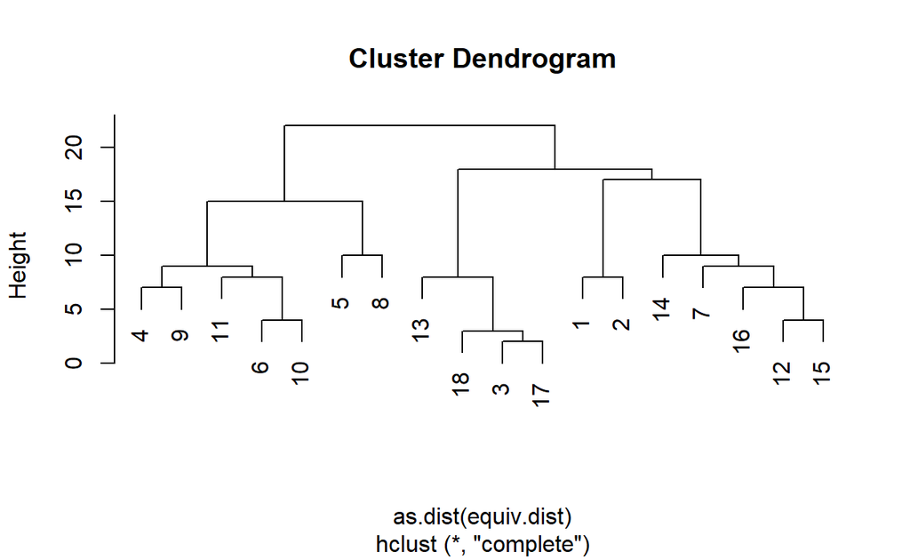

```r
plot(network.se)
```

### Equivalence Clustering

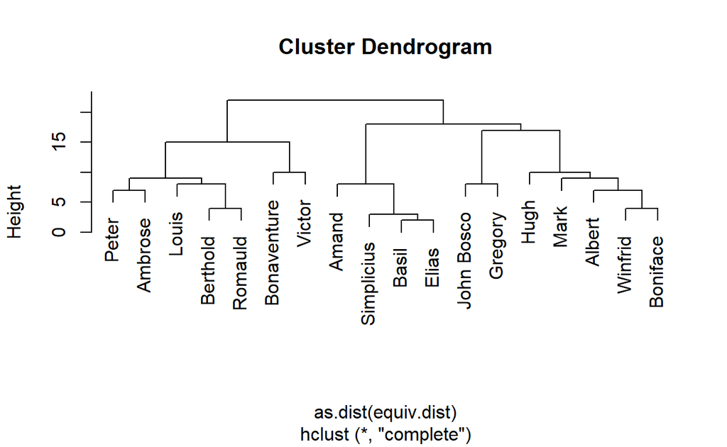

```r
plot(network.se,labels=network.se$glabels)
```

### Average Cluster Method

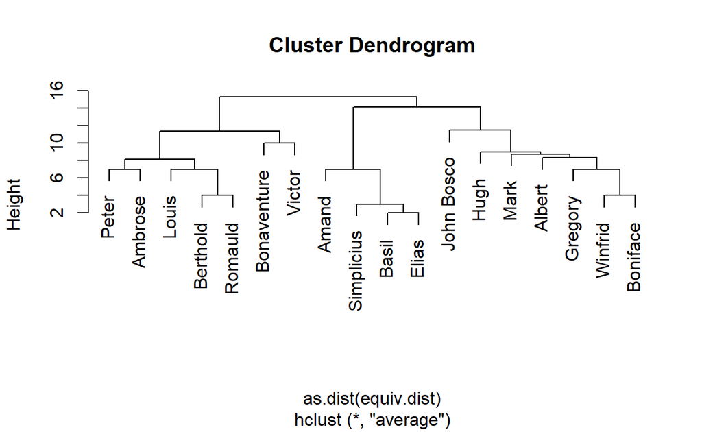

```r
#with average cluster.method
netork.avg.se<-equiv.clust(network_statnet, equiv.fun="sedist", cluster.method="average", method="hamming",mode="graph")

#plot:
plot(netork.avg.se,labels=network.se$glabels)
```

### Single Cluster Method

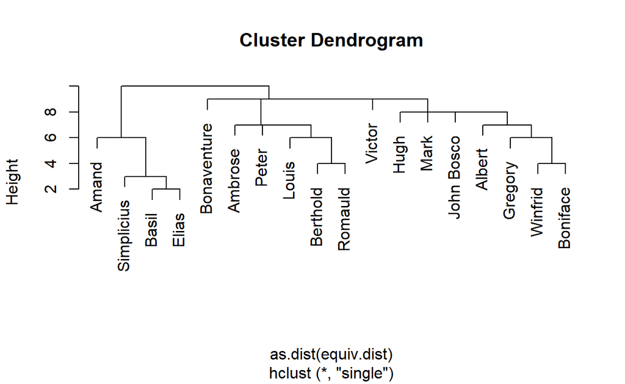

```r
#with single cluster.method
network.sing.se<-equiv.clust(network_statnet, equiv.fun="sedist", cluster.method="single", method="hamming",mode="graph")

#plot:
plot(network.sing.se,labels=network.se$glabels)
```

### Ward D cluster

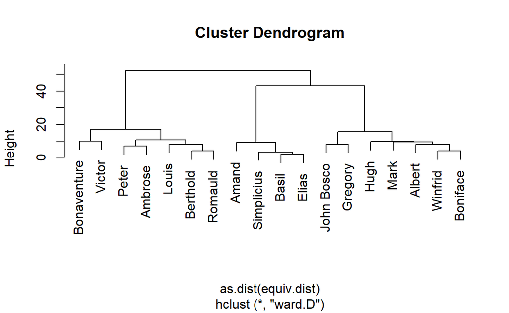

```r
#with ward.D cluster.method
network.wrd.se<-equiv.clust(network_statnet, equiv.fun="sedist", cluster.method="ward.D", method="hamming",mode="graph")

#plot:
plot(network.wrd.se,labels=network.se$glabels)
```

### Partition a Matrix Using Clustering**

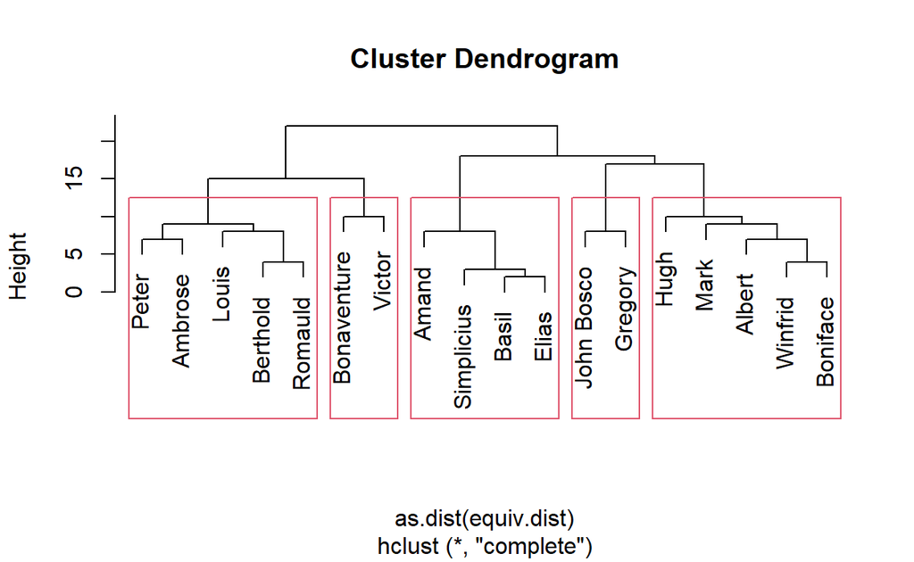

```r
#plot equivalence clustering
plot(network.se,labels=network.se$glabels)
#partition the clusters
rect.hclust(network.se$cluster,h=15)
```

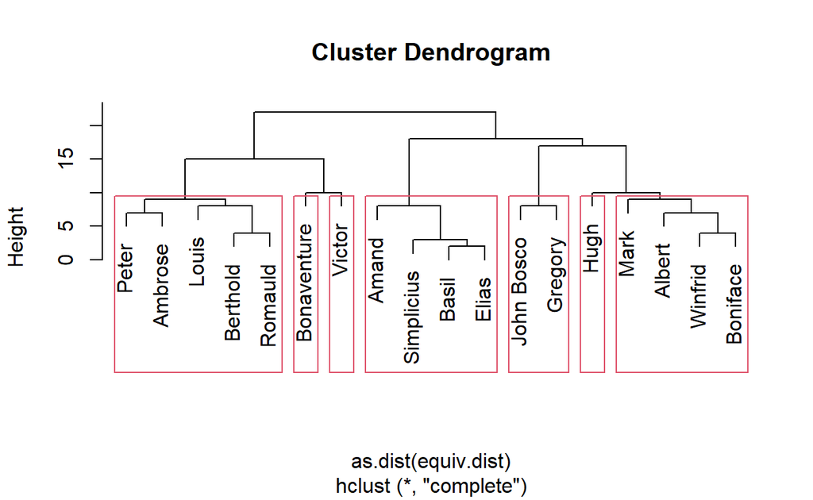

```r
#plot equivalence clustering
plot(network.se,labels=network.se$glabels)
#partition the clusters
rect.hclust(network.se$cluster,h=10)
```

## Block Models

```r
blk_mod <- blockmodel(network_statnet, network.se, k =2)
blk_mod
```

```
Network Blockmodel:

Block membership:

 John Bosco     Gregory       Basil       Peter Bonaventure
          1           1           1           2           2
   Berthold        Mark      Victor     Ambrose     Romauld
          2           1           2           2           2
      Louis     Winfrid       Amand        Hugh    Boniface
          2           1           1           1           1
     Albert       Elias  Simplicius
          1           1           1

Reduced form blockmodel:

     John Bosco Gregory Basil Peter Bonaventure Berthold Mark Victor Ambrose Romauld Louis Winfrid Amand Hugh Boniface Albert Elias Simplicius
          Block 1    Block 2
Block 1 0.4363636 0.07792208
Block 2 0.1428571 0.54761905
```

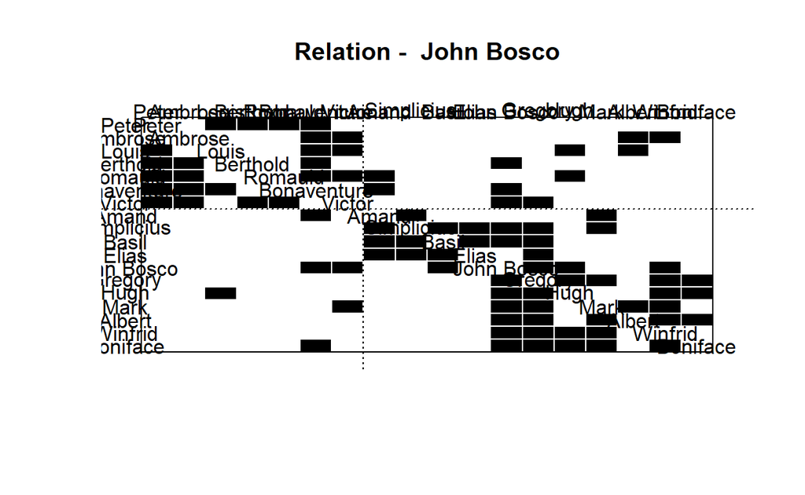

```r
plot(blk_mod)
```

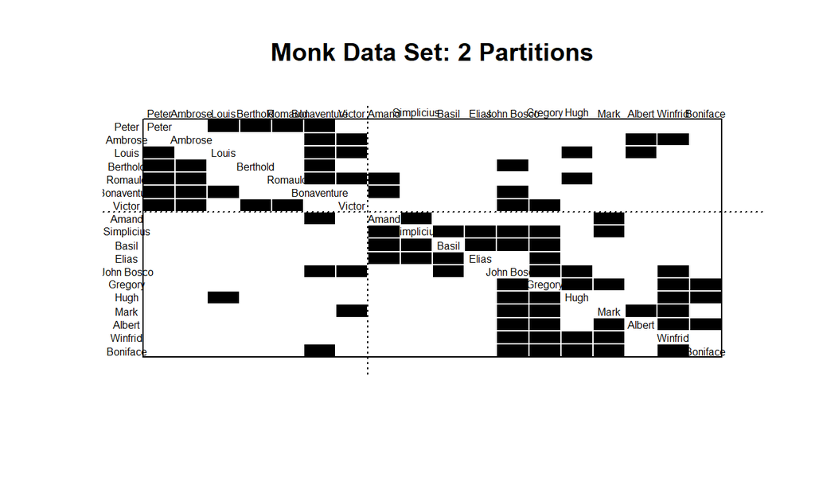

```r
plot.block<-function(x=blk_mod, main=NULL, cex.lab=1){
  plot.sociomatrix(x$blocked.data, labels=list(x$plabels,x$plabels),
                   main=main, drawlines = FALSE, cex.lab=cex.lab)
  for (j in 2:length(x$plabels)) if (x$block.membership[j] !=
                                     x$block.membership[j-1])
    abline(v = j - 0.5, h = j - 0.5, lty = 3, xpd=FALSE)
}



plot.block(blk_mod, main ="Monk Data Set: 2 Partitions", cex.lab = .5)
```

## Network Roles

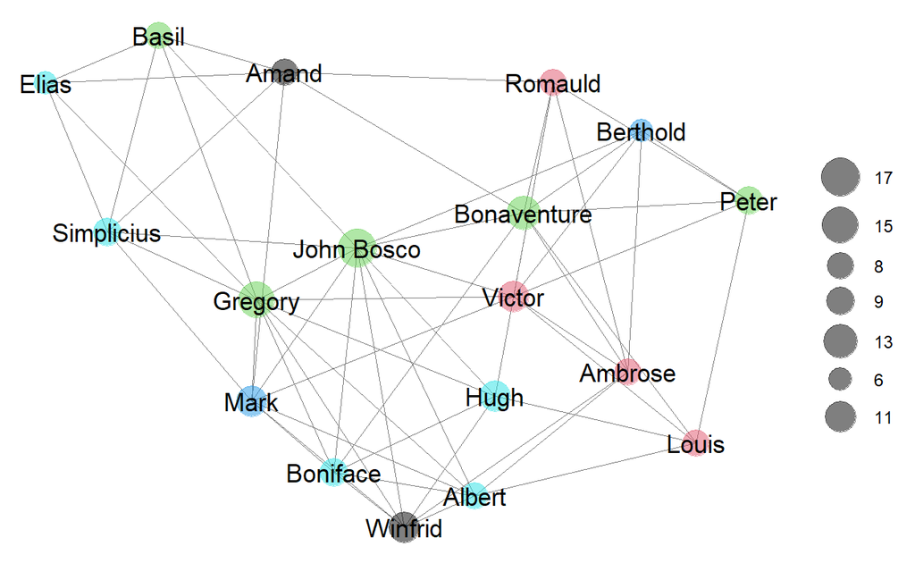

```r
#assign block membership to vertex attribute
blk_mod<-blockmodel(network_statnet,network.se,k=5)
V(network_igraph)$role<-blk_mod$block.membership[match(V(network_igraph)$name,blk_mod$plabels)]
network_statnet%v%"role"<-blk_mod$block.membership[match(network_statnet%v%"vertex.names", blk_mod$glabels)]



GGally::ggnet2(network_statnet,
               node.color="role",
               node.size=degree(network_igraph),
               node.label = "vertex.names",
               node.alpha = .5)
```

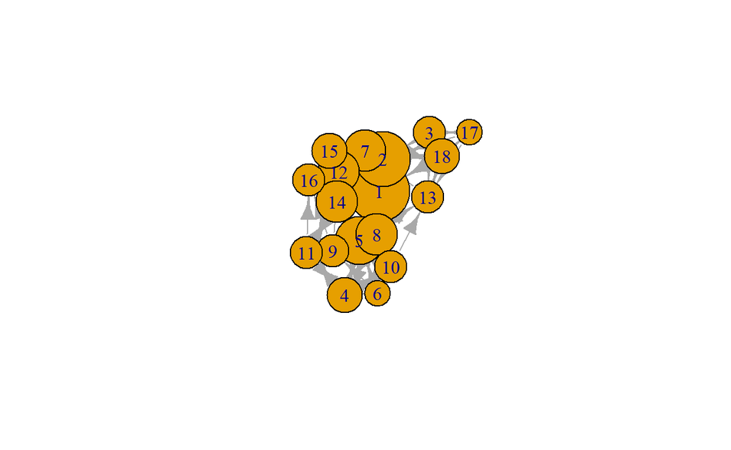

```r
plot.igraph(network_igraph,
            vertex.color=V(network_igraph)$role,
            vertex.size=8+(igraph::degree(network_igraph)*4))
```

## Comparing Network Role and Centrality

```r
network.nodes$role <- V(network_igraph)$role
network.nodes$role
```

[output not shown]

## Structural Equivalence: Weighted

```r
library(blockmodeling)
monks.mat <- as.matrix(as_adj(network_igraph, attr = "nominations"))
monks.mat %>% head()
```

```
     [,1] [,2] [,3] [,4] [,5] [,6] [,7] [,8] [,9] [,10] [,11] [,12]
[1,]    0    1    2    0    2    0    0    1    0     0     0     1
[2,]    3    0    0    0    0    0    3    0    0     0     0     2
[3,]    3    1    0    0    0    0    0    0    0     0     0     0
[4,]    0    0    0    0    3    3    0    0    0     1     2     0
[5,]    1    0    0    3    0    0    0    0    1     0     3     0
[6,]    2    0    0    3    1    0    0    0    3     0     0     0
     [,13] [,14] [,15] [,16] [,17] [,18]
[1,]     0     2     0     0     0     0
[2,]     0     1     1     0     0     0
[3,]     1     0     0     0     3     2
[4,]     0     0     0     0     0     0
[5,]     1     0     0     0     0     0
[6,]     0     0     0     0     0     0
```

```r
monks.sedist <- sedist(monks.mat)
monks.se <- equiv.clust(network_statnet, equiv.dist =  monks.sedist)
monks.se
```

```
Position Clustering:

    Equivalence function: sedist
    Equivalence metric: hamming
    Cluster method: complete
    Graph order: 18
```

## Optimized Based Partitions

```r
blks <- blockmodeling::optRandomParC(monks.mat, k = 5, rep =10, approaches = "ss", blocks = "com")
```

[output not shown]

```r
blk_mod <- blockmodel(network_statnet, blks$best$best1$clu, plabels = rownames(monks.mat))

blk_mod$block.model
```

```
           Block 1    Block 2 Block 3    Block 4   Block 5
Block 1 1.00000000 0.06666667    0.00 0.16666667 0.8333333
Block 2 0.00000000 0.60000000    0.10 0.06666667 1.0000000
Block 3 0.00000000 0.00000000    1.00 0.50000000 0.2500000
Block 4 0.05555556 0.20000000    0.75 0.30000000 0.2500000
Block 5 0.16666667 0.60000000    0.25 0.08333333 1.0000000
```

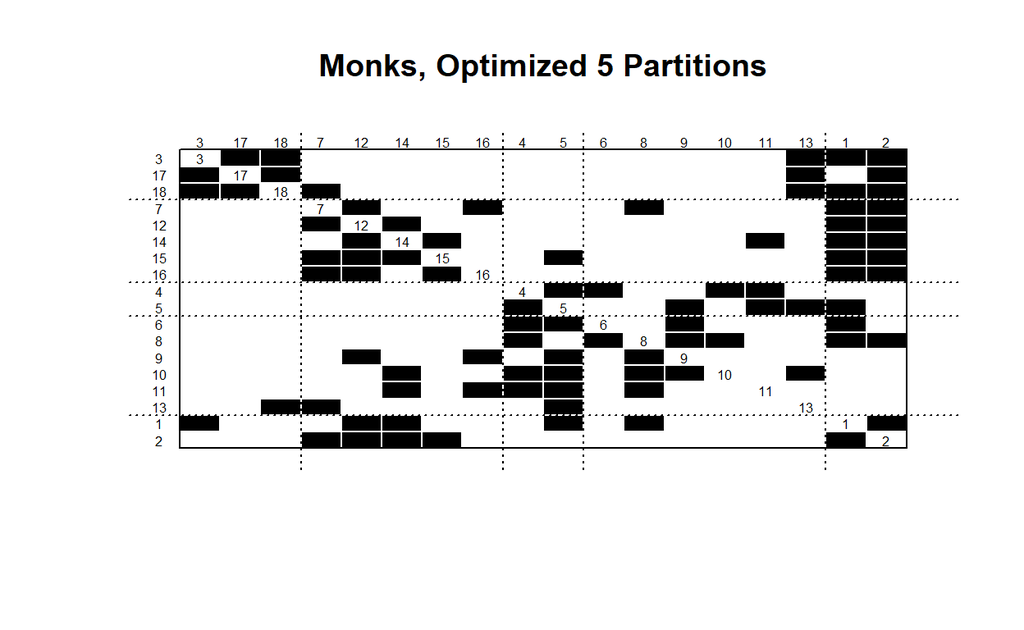

```r
plot.block(blk_mod, main = "Monks, Optimized 5 Partitions", cex.lab = .5)
```

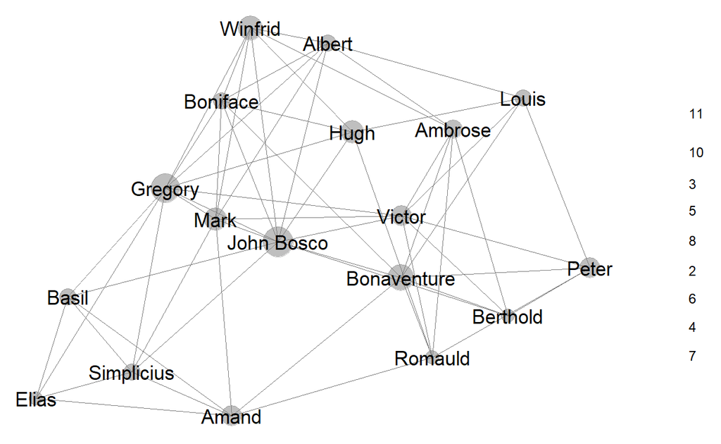

```r
network_statnet%v%"role"<-blk_mod$block.membership[match(network_statnet%v%"vertex.names",blk_mod$plabels)]
#plot network using "role" to color nodes
GGally::ggnet2(network_statnet,
               node.color="role",
                node.size = sna::degree(network_statnet, gmode = "graph"),
               node.label = "vertex.names",
               node.alpha = .5)
```

## Regular Equivalence

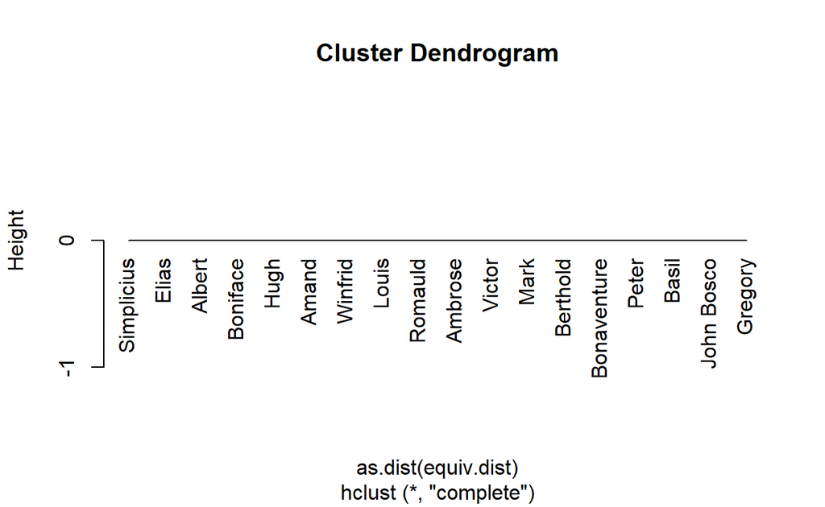

```r
#calculate equivalence from specified distance marix
network.re<-equiv.clust(network_statnet, equiv.fun="redist", method="catrege", mode="graph")
#plot equivalence clustering
plot(network.re,labels=network.se$glabels)
```